# Eigen Faces and PCA linear dimention reduction

## PCA implementation

To implement calss PCA, implementing methods `fit` and `transform`. Class requires `n_components` parameter in the constructor.

```python
import pandas as pd
import numpy as np
import matplotlib.pyplot as plt
%matplotlib inline

# write your code here
class PCA:
  def __init__(self,n_components):
    self.n_components = n_components
  def fit(self,X):
    centered_X = X-np.mean(X,axis=0)
    eigvals, eigvecs = np.linalg.eigh(np.cov(centered_X,rowvar=False))
    sorted_eigs_ind = np.argsort(eigvals)[::-1]
    sorted_eigvals = eigvals[sorted_eigs_ind]
    sorted_eigvecs = eigvecs[:,sorted_eigs_ind]
    self.pcs = -sorted_eigvecs[:,0:self.n_components]
  def transform(self,X):
    centered_X =  X-np.mean(X,axis=0)
    return np.dot(self.pcs.T,centered_X.T).T
```

Now, create some dataset using `sklearn` and implement fit and transform of your class at created data.

```python
from sklearn.datasets import load_breast_cancer
from sklearn.preprocessing import StandardScaler
data=load_breast_cancer()
print(*data['feature_names'],sep=', ')
df=pd.DataFrame(data['data'],columns=data['feature_names'])
sc = StandardScaler()
data = sc.fit_transform(df)
```

```
mean radius, mean texture, mean perimeter, mean area, mean smoothness, mean compactness, mean concavity, mean concave points, mean symmetry, mean fractal dimension, radius error, texture error, perimeter error, area error, smoothness error, compactness error, concavity error, concave points error, s…
```

Compare transformed data with one, obtainable using `PCA` implementation from `scikit-learn` library.

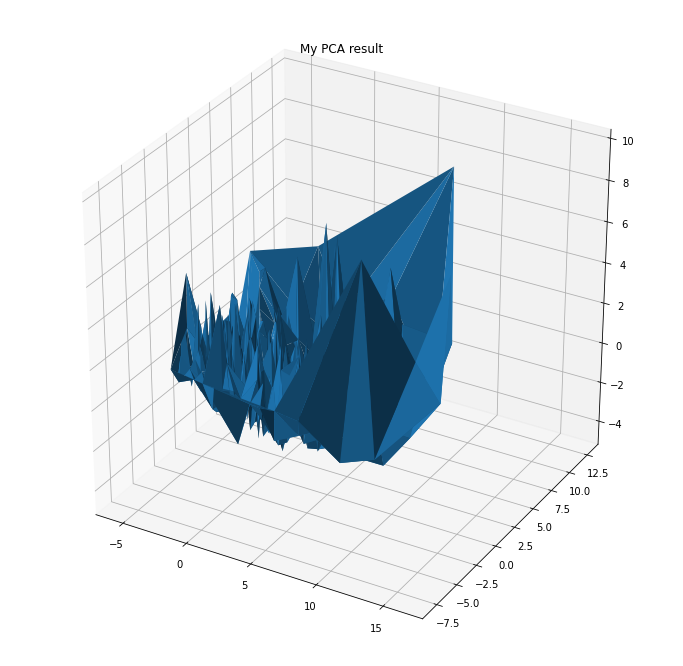

```python
# Import libraries
from mpl_toolkits import mplot3d
pca = PCA(3)
pca.fit(data)
downSampledData = pca.transform(data)
fig = plt.figure(figsize=(12, 12))
ax = fig.gca(projection='3d')
ax.plot_trisurf(downSampledData.T[0],downSampledData.T[1],downSampledData.T[2])
plt.title("My PCA result")
plt.show()
```

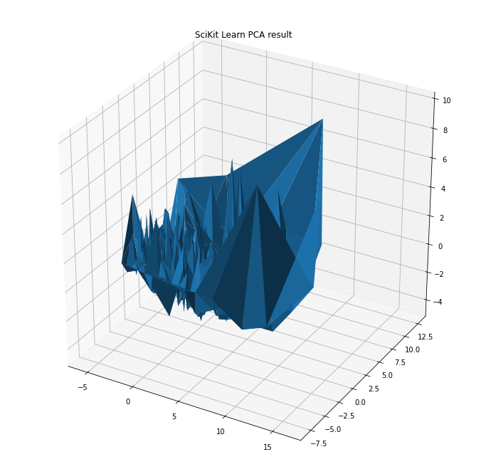

```python
# write your code here
from sklearn.decomposition import PCA as sk_PCA
sk_pca = sk_PCA(3)
sk_pca.fit(data)
downSampledData = sk_pca.transform(data)
fig = plt.figure(figsize=(12, 12))
ax = fig.gca(projection='3d')
# for x,y,z in
ax.plot_trisurf(downSampledData.T[0],downSampledData.T[1],downSampledData.T[2])
plt.title("SciKit Learn PCA result")
plt.show()
```

## Task 2. Basis faces (3 points)

Retrieve the data of the face dataset ([archive](https://drive.google.com/file/d/1lnc4AMFQPnkVOZ8p0RwHEcKa35XL1ZeD/view?usp=sharing), [folder](https://drive.google.com/drive/folders/1WLMQ3ZYx-_FqcM1nc6WDdzzOhG9di2hg?usp=sharing)). There are multiple face pictures in the context. The main thing is that faces are usually in the center of the image, so we may consider center of pictures to be samples from "face" subspace of an image space.

Your task is to find appropriate basis for that "face" subspace using PCA you implemented.

```python
# write your code here
# mount Google Drive
from google.colab import drive
drive.mount('/content/gdrive')
!tar -xvf '/content/gdrive/MyDrive/lfw-funneled.tgz'
```

[output not shown]

[output cut: 4946 more lines]

[output not shown]

```python
# write your code here
# from PIL import Image
import glob

from PIL import Image

N=1000
SIZE=(50,50)
def img2vec(path):
  # img = plt.imread(path)
  # return img.flatten()
  img = Image.open(path)
  img = img.resize(SIZE,Image.ANTIALIAS)
  return np.array(img).flatten()

subspace = np.array([img2vec(dir) for dir in glob.glob('/content/lfw_funneled/*/*.jpg')[:]]).T
```

```python
print(subspace.shape)
N_EIGFACE=64
myPCA = sk_PCA(N_EIGFACE)
myPCA.fit(subspace)
reduced_subspace = myPCA.transform(subspace).T
```

```
(7500, 13233)
```

Create function for face approximation visualization using first `N` basis-"faces".

```python
reduced_subspace.shape
```

```
(64, 7500)
```

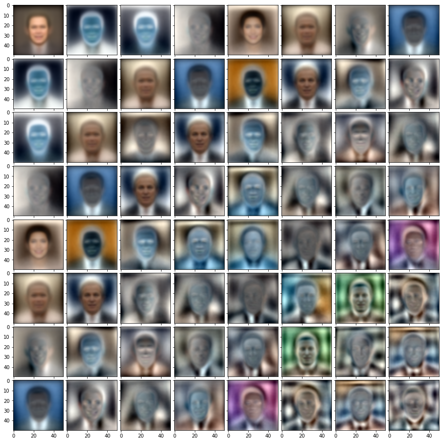

```python
from numpy.ma.core import reshape
# write your code here
shape=(50,50,3)

def vec2img(vec):
  new_vec = vec.reshape(shape)
  new_vec+= abs(np.min(new_vec))
  new_vec-= np.min(new_vec)
  new_vec /= np.max(new_vec)

  return new_vec

N_BASIS = 64
N_ROWS = 8


from mpl_toolkits.axes_grid1 import ImageGrid


fig = plt.figure(figsize=(16., 16.))
grid = ImageGrid(fig, 111,
                 nrows_ncols=(N_BASIS//N_ROWS,N_ROWS),
                 axes_pad=0.1,)

for ax, im in zip(grid, [ vec2img(reduced_subspace[(i+1)*(j+1)-1])
  for i in range(N_BASIS//N_ROWS)
    for j in range(N_ROWS)]):
  ax.imshow(im)

plt.show()
```

As you may notice, many basis faces have negative elements, although the data itself is purely non-negative. Why is it so, why do we have negative elements from mathematical point of view? In what cases negative elements may be absent in PCA projection vectors?

**Because in PCA we are interested in the eigenvectors of the subspace which has the larget covarince. in process of calculation of covariance matrix and centralization of the data(shifting the data by offset e.g mean) we will end up with posetive and negative and non-integer values.**

There are matrix decompositions, that may be more useful than SVD in particular cases. For example, non-negative matrix factorization. You should implement [it](https://en.wikipedia.org/wiki/Non-negative_matrix_factorization#Algorithms) and use at the face dataset.

```python
# write your code here
epsilon = 1e-10
def get_H(W, H, V):
    return H*((W.T.dot(V)) / (W.T.dot(W).dot(H) + epsilon))

def get_W(W, H, V):
    return W*((V.dot(H.T)) / (W.dot(H).dot(H.T) +epsilon))

def nnmf(V, rank, iter):

    # Initialize
    n, m = V.shape

    W = np.abs(np.random.randn(1, n, rank))[0]
    H = np.abs(np.random.randn(1, rank, m))[0]

    loss = []
    for i in range(iter):
        H = get_H(W, H, V)
        W = get_W(W, H, V)

        loss.append(sum((V - W.dot(H)).flatten()**2))

    return H, W, loss
H,W,loss = nnmf(subspace,N_EIGFACE,10)
```

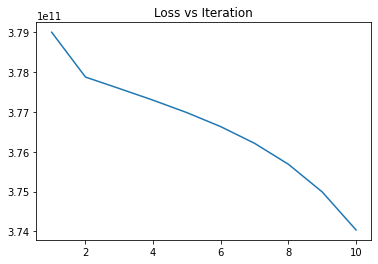

```
(7500, 64)
(64, 13233)
(7500, 13233)
[[False False False ... False False False]
 [False False False ... False False False]
 [False False False ... False False False]
 ...
 [False False False ... False False False]
 [False False False ... False False False]
 [False False False ... False False False]]
```

```python
plt.plot(range(1,11),loss)
plt.title('Loss vs Iteration')
plt.show()
print(W.shape)
print(H.shape)
print(subspace.shape)
print(W@H==subspace)
```

Do not forget to check, that $W H = V$.  
Which of those matrices contains basis faces? Why do you think so? What is inside the second matrix?

**I think W contains the basis faces because of the shape of the matrix. and I think the second matrix contains the rest of the subspace which is not concidered as the basis of the face subspace.**

Compare first five basis faces created by PCA and by NNMF. Write down your observations.

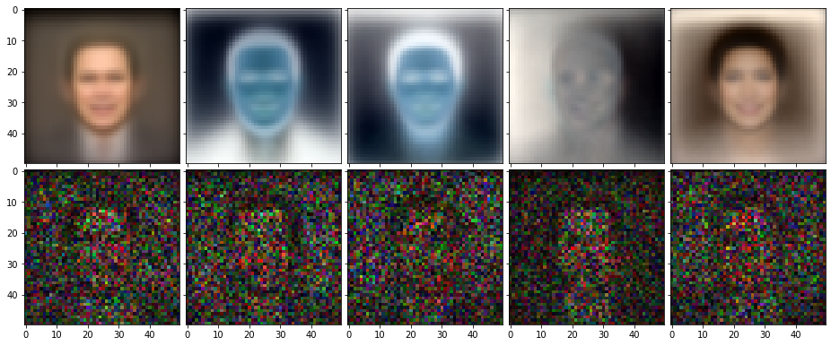

```python
fig = plt.figure(figsize=(16., 16.))
grid = ImageGrid(fig, 111,
                 nrows_ncols=(10//5,5),
                 axes_pad=0.1,)

for ax, im in zip(grid, [vec2img(reduced_subspace[i])for i in range(5)]+[ vec2img(W.T[i])for i in range(5)]):
  ax.imshow(im)

plt.show()
```

**I can observer that PCA results in a clear results since it utilizes analytical solution for obtaining the components of the face subspace meanwhile NNMF basis are more noisy due to small number of iterations and big loss. however this loss can approach to zero by increment of the iterations.**

## Task 3. Important features (1 point)

Analyze data from the previous task and highlight the pixels having the greatest variability across the images. Use heatmap for visualization, display it over images from the dataset.

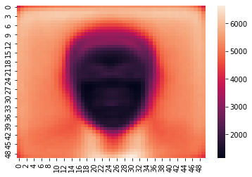

```python
# write your code here
# 10X10 array
import seaborn as sns

Mvar = np.var(subspace,axis=1).reshape(shape)
r, g, b = Mvar[:,:,0], Mvar[:,:,1], Mvar[:,:,2]
Mvar_gray = 0.2989 * r + 0.5870 * g + 0.1140 * b

sns.heatmap(Mvar_gray)
plt.Figure(figsize=(8,8))
plt.show()
```